# Compito di Statistica

Scrivere in stampatello

| COGNOME | $\LARGE\square$ | $\LARGE\square$ | $\LARGE\square$ | $\LARGE\square$ | $\LARGE\square$ | $\LARGE\square$ | $\LARGE\square$ | $\LARGE\square$ | $\LARGE\square$ | $\LARGE\square$ | $\LARGE\square$ | $\LARGE\square$ | $\LARGE\square$ | $\LARGE\square$ | $\LARGE\square$ | $\LARGE\square$ | $\LARGE\square$ | $\LARGE\square$ | $\LARGE\square$ | $\LARGE\square$ |
| --- | --- | --- | --- | --- | --- | --- | --- | --- | --- | --- | --- | --- | --- | --- | --- | --- | --- | --- | --- | --- |
| NOME | $\LARGE\square$ | $\LARGE\square$ | $\LARGE\square$ | $\LARGE\square$ | $\LARGE\square$ | $\LARGE\square$ | $\LARGE\square$ | $\LARGE\square$ | $\LARGE\square$ | $\LARGE\square$ | $\LARGE\square$ | $\LARGE\square$ | $\LARGE\square$ | $\LARGE\square$ | $\LARGE\square$ | $\LARGE\square$ | $\LARGE\square$ | $\LARGE\square$ | $\LARGE\square$ | $\LARGE\square$ |
| Matricola | $\LARGE\square$ | $\LARGE\square$ | $\LARGE\square$ | $\LARGE\square$ | $\LARGE\square$ | $\LARGE\square$ | $\LARGE\square$ | $\LARGE\square$ | $\LARGE\square$ | $\LARGE\square$ | $\LARGE\square$ | $\LARGE\square$ | $\LARGE\square$ | $\LARGE\square$ | $\LARGE\square$ | $\LARGE\square$ | $\LARGE\square$ | $\LARGE\square$ | $\LARGE\square$ | $\LARGE\square$ |
| CDL | $\LARGE\square$ | $\LARGE\square$ | $\LARGE\square$ | $\LARGE\square$ | $\LARGE\square$ |  |  |  |  |  |  |  |  |  |  |  |  |  |  |  |

### Esercizio 1

Su un campione di $200$ imprese della provincia di Modena è stato rilevato l’utile dell’ultimo trimestre (espresso in migliaia di euro). Qui di seguito la distribuzione delle frequenze assolute:

| $[\text{x}_j,$ | $\text{x}_{j+1})$ | $n_j$ |
| --- | --- | --- |
| -2 | -1 | 17 |
| -1 | 1 | 83 |
| 1 | 5 | 92 |
| 5 | 15 | 8 |
|  |  | 200 |

1.a (**Punti 14 su 100 (4.2 su 30)**) Individuare la classe modale.

| $[\text{x}_j,$ | $\text{x}_{j+1})$ | $n_j$ | $f_j$ | $b_j$ | $h_j$ | $F_j$ |
| --- | --- | --- | --- | --- | --- | --- |
| -2 | -1 | 17 | 0.085 | 1 | 8.50 | 0.085 |
| -1 | 1 | 83 | 0.415 | 2 | 20.75 | 0.500 |
| 1 | 5 | 92 | 0.460 | 4 | 11.50 | 0.960 |
| 5 | 15 | 8 | 0.040 | 10 | 0.40 | 1.000 |
|  |  | 200 | 1.000 | 17 |  |  |

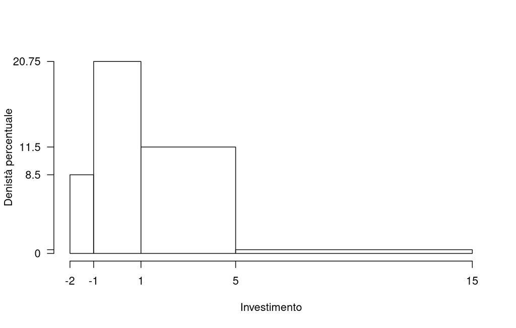

1.b (**Punti 3 su 100 (0.9 su 30)**) Quale è il numero di imprese che hanno un utile maggiore di zero?

$$\begin{eqnarray*}
\%(X>0) &=& 100\%-\%(X\le 0)\\
&=& 100 - (0.09\times 100 + 20.8\times(0-(-1)))\%\\
&=& 70.75\%
\end{eqnarray*}$$

1.d (**Punti 2 su 100 (0.6 su 30)**) Qual è la proprietà di associatività della media aritmetica?

### Esercizio 2

Siano $X\sim N(5,1/2)$ e sia $Y\sim N(5,1/2)$, $X$ e $Y$ indipendenti. Posto $A=\{X>6\}$, $B=\{Y<4\}$.

2.a (**Punti 14 su 100 (4.2 su 30)**) Calcolare $P(A\cup B)$.

$$\begin{eqnarray*}
P(X > 6)
&=& P\left( \frac {X - \mu}{\sigma} > \frac {6 -
5}{\sqrt{0.5}} \right) \\
&=& P\left( Z > 1.41\right) \\ &=&
1-P(Z< 1.41 )\\
&=& 1-\Phi( 1.41 ) \\ &=& 0.0793
\end{eqnarray*}$$

$$\begin{eqnarray*}
P(Y < 4)
&=& P\left( \frac {Y - \mu_Y}{\sigma_Y} < \frac {4 -
5}{\sqrt{0.5}} \right) \\
&=& P\left( Z < -1.41\right) \\
&=& 1-\Phi( 1.41 ) \\ &=& 0.0793
\end{eqnarray*}$$

e quindi

$$\begin{eqnarray*}
P(A\cup B) &=& P(A)+P(B)-P(A\cap B)\\
&=& 0.0786+0.0786-0.0786\times0.0786\\
&=& 0.1511
\end{eqnarray*}$$

2.b (**Punti 3 su 100 (0.9 su 30)**) Posto $Z=X-Y$, Calcolare la probabilità che $P(Z>1|Z\le 2)$.

$$\begin{eqnarray*}
Z &=& X-Y\\
&\sim& N(5-5,1/2+1/2)\\
&\sim& N(0,1)\\
P(Z>1|Z\le 2) &=&\frac{P(\{Z>1\}\cap\{Z\le 2\})}{P(Z\le
2)} \\
&=& \frac{P(1<Z\le 2)}{P(Z\le 2)} \\
&=&\frac{\Phi(2)-\Phi(1)}{\Phi(2)}\\
&=&\frac{0.9772-0.8413}{0.9772}\\
&=&0.1391
\end{eqnarray*}$$

2.c (**Punti 2 su 100 (0.6 su 30)**) Siano $A$ e $B$ due eventi diversi dal vuoto. Sono noti $P(A|B)=0.3$, $P(A|\bar B)=0.15$. $A$ e $B$ sono indipendenti? Perché?

No, perché se lo fossero
$$P(A|B)=P(A|\bar B)=P(A)$$

2.d (**Punti 2 su 100 (0.6 su 30)**) Sia $X\sim\text{Pois}(\lambda=1)$, disegnare la funzione di ripartizione $F(x)$ di $X$, per $x$ compreso tra $-1$ e $2.5$.

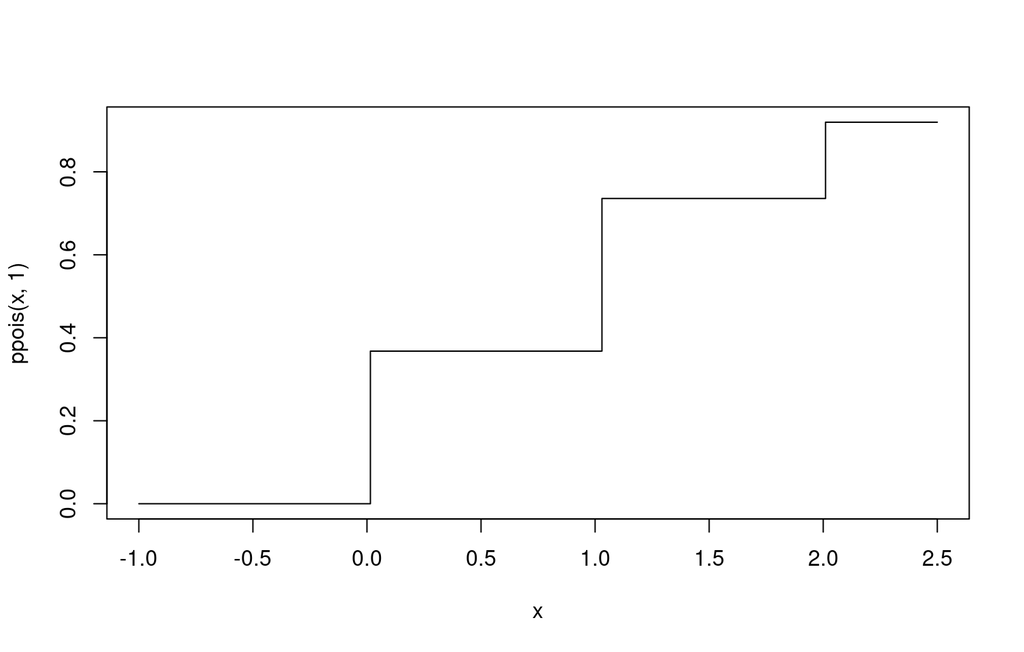

### Esercizio 3

(**Punti 14 su 100 (4.2 su 30)**) Una catena di montaggio a ciclo continuo produce un pezzo al giorno e la proporzione di pezzi fallati è pari a $\pi=0.15$.

Calcolare la probabilità che il numero totale di pezzi fallati in un anno ($n=365$) sia maggiore di 60

**Teorema del Limite Centrale (somma di Bernoulli)**

Siano $X_1$,…,$X_n$, $n=365$ VC IID, tc $X_i\sim\text{Ber}(\pi=0.15)$$,\forall i$, posto:
$$S_n = X_1 + ... + X_n$$
allora:
$$\begin{eqnarray*}
S_n & \mathop{\sim}\limits_{a}& N(n\pi,n\pi(1-\pi)) \\
&\sim & N(365\cdot0.15,365\cdot0.15\cdot(1-0.15)) \\
&\sim & N(54.75,46.54)
\end{eqnarray*}$$

$$\begin{eqnarray*}
P(S_n > 60)
&=& P\left( \frac {S_n - n\pi}{\sqrt{n\pi(1-\pi)}} > \frac
{60 - 54.75}{\sqrt{46.5375}} \right) \\
&=& P\left( Z > 0.77\right) \\ &=&
1-P(Z< 0.77 )\\
&=& 1-\Phi( 0.77 ) \\ &=& 0.2206
\end{eqnarray*}$$

### Esercizio 4

4.a (**Punti 3 su 100 (0.9 su 30)**) Sia $h$ uno stimatore per $\theta$, tale che
$$\begin{eqnarray*}
E(h)&=&\theta+\frac\theta {n^2},\\
V(h)&=&\frac{\sqrt\theta}{ n}.
\end{eqnarray*}$$
Ricavare $MSE(h)$, il Mean Squared Error di $h$.

$$\begin{eqnarray*}
MSE(h)&=&V(h)+B^2(h)\\
&=&V(h)+|E(h)-\theta|^2\\
&=&\frac{\sqrt\theta}{ n}+\left|\theta+\frac\theta
{n^2}-\theta\right|^2\\
&=&\frac{\sqrt\theta}{ n}+\frac{\theta^2} { n^4}\\
\end{eqnarray*}$$

4.b (**Punti 3 su 100 (0.9 su 30)**) Scrivere la funzione di verosimiglianza di una Poisson.

Siano $X_1,...,X_n$, $n$ VC IID, tali che, $X_i\sim\text{Pois}(\lambda)$ La verosimiglianza è
$$\begin{eqnarray*}
L(\lambda) &=&
\prod_{i=1}^n\frac{\lambda^{x_i}}{x_i!}e^{-\lambda}\\
&\propto& \lambda^{s_n} e^{-n\lambda},\qquad
s_n=\sum_{i=1}^n x_i
\end{eqnarray*}$$

4.c (**Punti 3 su 100 (0.9 su 30)**) Definire il $p_{\text{value}}$, la probabilità di significatività osservata.

La probabilità di significatività $p_{\text{value}}$ è

$$p_{\text{value}}=P(|T|>|t_{\text{obs}}|;H_0)$$

La probabilità di significatività osservata $p_\text{value}$ esprime la probabilità, *se fosse vera* $H_0$, di trovare un campione ancora più in favore di $H_1$ di quello disponile

### Esercizio 5

|  | Integratori alto | Integratori medio | Integratori basso | Integratori Totale |
| --- | --- | --- | --- | --- |
| **rendimento** |  |  |  |  |
| buono | 21 | 18 | 26 | 65 |
| scarso | 20 | 35 | 38 | 93 |
| Totale | 41 | 53 | 64 | 158 |

Testare al livello di significatività del 5% se c’è indipendenza tra integratori e rendimento.

|  | Integratori alto | Integratori medio | Integratori basso |
| --- | --- | --- | --- |
| **rendimento** |  |  |  |
| buono | 16.87 | 21.8 | 26.33 |
| scarso | 24.13 | 31.2 | 37.67 |

|  | Integratori alto | Integratori medio | Integratori basso |
| --- | --- | --- | --- |
| **rendimento** |  |  |  |
| buono | 1.0127 | 0.6636 | 0.0041 |
| scarso | 0.7078 | 0.4638 | 0.0029 |

Il chi oss è 2.855 , il chi-teorico, 5.991 rifiuto: no

### Esercizio 6

Sono stati analizzati 15 comuni della provincia di Bologna e su ogni comune è stato rilevato il PIL pro capite del comune $X$, espresso in decine di migliaia di euro e un valore di percezione di qualità della vita $Y$ (espresso su opportuna scala).

Qui di seguito le statistiche bivariate

$$\begin{align}
\sum_{i=1}^n x_i &= 28.3 &\sum_{i=1}^n x_i^2 &= 71.19
&\sum_{i=1}^n x_i y_i &= 253.01\\
\sum_{i=1}^n y_i &= 122.2 & \sum_{i=1}^n y_i^2 &= 1042.2
&
\end{align}$$

6.a (**Punti 14 su 100 (4.2 su 30)**) Questi sono alcuni dei dati osservati

| $x_i$ | 2.5 | 2.1 | 0.3 | 3.0 |
| --- | --- | --- | --- | --- |
| $y_i$ | 6.7 | 9.3 | 6.0 | 9.5 |

Calcolare il residuo per $x=2.1$ nel modello di regressione dove $Y$ è spiegato da $X$.

$$\begin{eqnarray*}
\bar x &=&\frac 1 n\sum_{i=1}^n x_i = \frac {1}{15} 28.3=
1.8867\\
\bar y &=&\frac 1 n\sum_{i=1}^n y_i = \frac {1}{15} 122.2=
8.1467\\
\hat\sigma_X^2&=&\frac 1 n\sum_{i=1}^n x_i^2-\bar x^2=\frac
{1}{15} 71.19 -1.8867^2=1.1865\\
\hat\sigma_Y^2&=&\frac 1 n\sum_{i=1}^n y_i^2-\bar y^2=\frac
{1}{15} 1042.2 -8.1467^2=3.1118\\
\text{cov}(X,Y)&=&\frac 1 n\sum_{i=1}^n x_i~y_i-\bar x\bar
y=\frac {1}{15} 253.01-1.8867\cdot8.1467=1.4973\\
\hat\beta_1 &=& \frac{\text{cov}(X,Y)}{\hat\sigma_X^2} \\
&=& \frac{1.4973}{1.1865} = 1.2619\\
\hat\beta_0 &=& \bar y - \hat\beta_1 \bar x\\
&=& 8.1467-1.2619\times 1.8867=5.7658
\end{eqnarray*}$$

$$\begin{eqnarray*}
\hat y_i &=&\hat\beta_0+\hat\beta_1 x_i=\\
&=& 5.766 + 1.2619 \times 2.1 = 8.416 \\
\hat \varepsilon_i &=& y_i-\hat y_i\\
&=& 9.3 - 8.416 = 0.8841
\end{eqnarray*}$$

6.b (**Punti 3 su 100 (0.9 su 30)**) Calcolare la percentuale di varianza di $Y$ spiegata dal modello.

$$\begin{eqnarray*}
r&=&\frac{\text{cov}(X,Y)}{\sigma_X\sigma_Y}=\frac{ 1.497 }{
1.089 \times 1.764 }= 0.7792 \\r^2&=& 0.6072 < 0.75
\end{eqnarray*}$$
Il modello **non** si adatta bene ai dati.

6.c (**Punti 2 su 100 (0.6 su 30)**) Se in un modello di regressione con 15 dati, il residuo studentizzato del dato $i$ è $\tilde \epsilon_i=12.3$, cosa possiamo concludere?

6.d (**Punti 2 su 100 (0.6 su 30)**) Sia $\hat\beta_0$ lo stimatore dei minimi quadrati per $\beta_0$. Scrivere il suo Standard Error stimato.